# CC_showcase

THE TRADE IDEA

This is a mean reversion trade of my own creation, which proved very profitable. ASX bond futures trade 24 hrs. But what do they do during the ASX overnight session? Given Asia is asleep, all they really can do is follow the US bonds around. Mostly.

NOTE this is a not a fully automated trade. Macro must be monitored for divergent CB policy. And please, always have a hard stop out.

Just for fun we are going to ingest 1 minute data, and then resample it to 30.

DATA PREPARATION

```python
import backtrader as bt
import datetime
import matplotlib.pyplot as plt
import numpy as np
import pandas as pd
import pytz
from pytz import timezone
#from tabulate import tabulate
# Increase the no. of rows printed
pd.set_option('display.max_rows', 250)
```

```python
# We are going to be resampling, and ffilling. So we will need a function to remove the weekends.

def weekend_remover(dts, start_day, start_time, end_day, end_time):
    '''
    datetime.datetime, int, datetime.time(), int, datetime.time() ----> bool

    Checks datetime for whether it is within our definition of "the weekend".
    REQUIREMENT datetime. Returns True if timestamp is within the weekend.
    '''
    if dts.weekday() < start_day:
        return False
    elif (dts.weekday() == start_day) & (dts.time() < start_time):
        return False
    elif dts.weekday() > end_day:
        return False
    elif (dts.weekday() == end_day) & (dts.time() > end_time):
        return False
    else:
        return True
```

```python
# Import data. 1 min data, rolled, ffilled, and back-adjusted. And all in local timezones.
dateparse = lambda x: datetime.datetime.strptime(x, '%Y-%m-%d %H:%M')

# CBOT 10yr
source1 = 'C:/Users/CM/Documents/ASX_CBOT/TY_adj.csv'
df_ty = pd.read_csv(source1, index_col='Date and Time', parse_dates=['Date and Time'], date_parser=dateparse)
df_ty.drop('Volume', axis=1, inplace=True)
df_ty.columns = ['TY']

# CBOT 2yr
source2 = 'C:/Users/CM/Documents/ASX_CBOT/TU_adj.csv'
df_tu = pd.read_csv(source2, index_col='Date and Time', parse_dates=['Date and Time'], date_parser=dateparse)
df_tu.drop('Volume', axis=1, inplace=True)
df_tu.columns = ['TU']

# Merge the two
df_cbot = pd.concat([df_tu, df_ty], axis=1)

# For this trade we will be looking at 24hr markets. CBOT began 23hr trading in Oct 2011.
df_cbot = df_cbot.loc['2011-10-02':]
# Specify local time zone
df_cbot = df_cbot.tz_localize('America/Chicago', ambiguous=True)
# Resample
df_cbot = df_cbot.resample('30T').ffill()
# Market closes are ffilled, so lets remove those first.
df_cbot = df_cbot.between_time('17:00:01', '16:00:00') # the times are included.
# Now for the weekends below. Weekend is FRI 17:45 to SUN 17:00.
df_cbot['dt_temp'] = df_cbot.index.to_series()
df_cbot['filter'] = df_cbot['dt_temp'].apply(lambda x: weekend_remover(x, 4, datetime.time(17, 45),
                                                                   6, datetime.time(17, 0)))
df_cbot = df_cbot.loc[df_cbot['filter'] == False, ['TU', 'TY']]
```

```python
# ASX 10yr
source3 = 'C:/Users/CM/Documents/ASX_CBOT/AX_adj.csv'
df_xt = pd.read_csv(source3, index_col='Date and Time', parse_dates=['Date and Time'], date_parser=dateparse)
df_xt.drop('Volume', axis=1, inplace=True)
df_xt.columns = ['XT']

# ASX 3yr
source4 = 'C:/Users/CM/Documents/ASX_CBOT/AY_adj.csv'
df_yt = pd.read_csv(source4, index_col='Date and Time', parse_dates=['Date and Time'], date_parser=dateparse)
df_yt.drop('Volume', axis=1, inplace=True)
df_yt.columns = ['YT']

# Merge the two
df_asx = pd.concat([df_yt, df_xt], axis=1)

# Specify local time zone
df_asx = df_asx.tz_localize('Australia/NSW', ambiguous=True)
# Resample
df_asx = df_asx.resample('30T').ffill()
# ASX closes twice per 24H session
df_asx = df_asx.between_time('17:13', '16:30')
df_asx = df_asx.between_time('08:33', '07:00')
# Now for the weekends below. Weekend is SAT 07:00 to MON 08:32.
df_asx['dt_temp'] = df_asx.index.to_series()
df_asx['filter'] = df_asx['dt_temp'].apply(lambda x: weekend_remover(x, 5, datetime.time(7, 0),
                                                                   0, datetime.time(8, 32)))
df_asx = df_asx.loc[df_asx['filter'] == False, ['YT', 'XT']]
```

```python
# Merging two differing timezone, the result df is now in UTC.
df = pd.concat([df_cbot, df_asx], axis=1)
df.dropna(inplace=True)
```

```python
# Beyond the scope of this example, I have pre-calculated the contract ratio that we will be
# using. Method includes cointegration measures, and the variable ASX contract tick value.
df['Box'] = df['TU']*0.45-df['TY']*0.105-df['YT']+df['XT']
df.head()
```

| Date and Time | TU | TY | YT | XT | Box |
| --- | --- | --- | --- | --- | --- |
| 2011-10-02 22:30:00+00:00 | 106.542969 | 109.625000 | 96.587 | 94.9545 | 34.801211 |
| 2011-10-02 23:00:00+00:00 | 106.535156 | 109.578125 | 96.577 | 94.9445 | 34.802617 |
| 2011-10-02 23:30:00+00:00 | 106.535156 | 109.500000 | 96.557 | 94.9245 | 34.810820 |
| 2011-10-03 00:00:00+00:00 | 106.535156 | 109.500000 | 96.567 | 94.9345 | 34.810820 |
| 2011-10-03 00:30:00+00:00 | 106.535156 | 109.515625 | 96.567 | 94.9295 | 34.804180 |

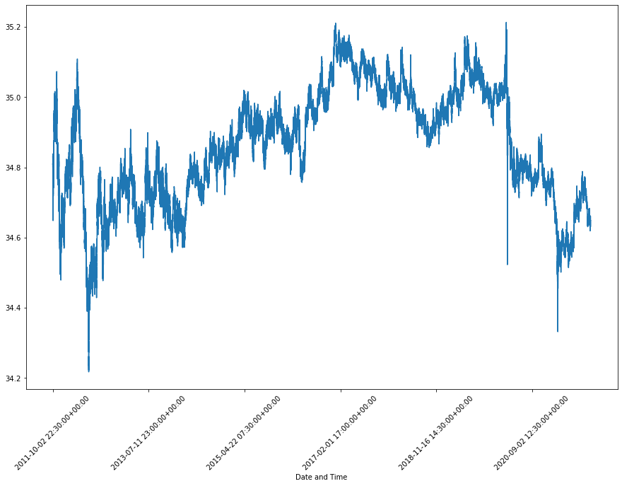

```python
# Let's increase the plot size a little.
plt.rcParams['figure.figsize'] = [15, 10]
# And set plot x-axis as string so that matplotlib doesn't try to fill in weekends.
x= df.set_index(df.index.astype('str'))
x['Box'].plot(rot=45); plt.show()
```

```python
# Prep done, let's save a copy.
source_out = 'C:/Users/CM/Documents/ASX_CBOT/Prepped_ASX_CBOT_data.csv'
df.to_csv(source_out, header=True, date_format='%Y-%m-%d %H:%M:%S %Z', float_format='%.7f')
# Clean up the frames in memory.
dataframes = [df_ty, df_tu, df_xt, df_yt, df_asx, df_cbot]
for frame in dataframes:
    frame = ''
```

```python
# For the BackTrader we will need some OHLC data. Because we have created a spread, we must do this synthetically.
df.drop(['TU', 'TY', 'YT', 'XT'], axis=1, inplace=True)
df.rename(columns={'Box': 'Close'}, inplace=True)
df['Open'] = df['Close'].shift(1)
df['High'] = np.maximum(df['Open'], df['Close'])
df['Low'] = np.minimum(df['Open'], df['Close'])
df = df.dropna()
```

```python
df.head()
```

| Date and Time | Close | Open | High | Low |
| --- | --- | --- | --- | --- |
| 2011-10-02 23:00:00+00:00 | 34.802617 | 34.801211 | 34.802617 | 34.801211 |
| 2011-10-02 23:30:00+00:00 | 34.810820 | 34.802617 | 34.810820 | 34.802617 |
| 2011-10-03 00:00:00+00:00 | 34.810820 | 34.810820 | 34.810820 | 34.810820 |
| 2011-10-03 00:30:00+00:00 | 34.804180 | 34.810820 | 34.810820 | 34.804180 |
| 2011-10-03 01:00:00+00:00 | 34.807539 | 34.804180 | 34.807539 | 34.804180 |

Backtesting. Here I will be using Backtrader. Not the fastest backtester out there, but feature-rich, and event-driven testing.

Word to the wise. This trade was extremely effective up to the CB response to covid19. But the spreads blew out ofter given divergent methods of dealing with the crisis. ALWAYS think about whether what you are doing makes logical sense. Plus *disciplined* use of hard stops!

BACKTEST

```python
# Create a Stratey
class TestStrategy(bt.Strategy):
    params = (
        ('bbandsperiod', 218),
        ('bbdevfactor', 2.0),
        ('bbandsperiod2', 218),
        ('bbdevfactor2', 0.5),
        ('entrytime', datetime.time(14, 0)),
        ('exittime', datetime.time(9, 0)),
        ('maxlong', 7),
        ('maxshort', -7),
        ('stop', 100),
    )

    def log(self, txt, dt=None):
        ''' Logging function for this strategy'''
        dt = dt or self.datas[0].datetime.datetime(0)
        # If you want to print out each trade:
#         print('%s, %s' % (dt.isoformat(), txt))

    def __init__(self):
        # Keep a reference to the "close" line in the data[0] dataseries
        self.dataclose = self.datas[0].close
        self.count = len(self)
        # To keep track of pending orders and trade price/commission
        self.order = None
        self.buyprice = None
        self.buycomm = None
        self.sellprice = None
        self.sellcomm = None

        # Add indicators
        self.bband = bt.indicators.BBands(self.datas[0], period=self.params.bbandsperiod,
                                          devfactor=self.params.bbdevfactor)
        self.bband2 = bt.indicators.BBands(self.datas[0], period=self.params.bbandsperiod2,
                                           devfactor=self.params.bbdevfactor2)


        self.wind = pd.to_datetime(('14:30:00', '15:00:00', '15:30:00',
                                    '16:00:00', '16:30:00'), format='%H:%M:%S')
        self.extimes = pd.to_datetime(('15:12:00', '16:12:00'), format='%H:%M:%S')


    def notify_order(self, order):
        if order.status in [order.Submitted, order.Accepted]:
            # Buy/Sell order submitted/accepted to/by broker - Nothing to do
            return

        # Check if an order has been completed
        # Attention: broker could reject order if not enough cash
        if order.status in [order.Completed]:
            if order.isbuy():
                self.log(
                    'BUY EXECUTED, Price: %.2f, Cost: %.2f, Comm %.2f' %
                    (order.executed.price,
                     order.executed.value,
                     order.executed.comm))

                self.buyprice = order.executed.price
                self.buycomm = order.executed.comm
                self.buytarget = self.buyprice + 10
            else:  # Sell
                self.log('SELL EXECUTED, Price: %.2f, Cost: %.2f, Comm %.2f' %
                         (order.executed.price,
                          order.executed.value,
                          order.executed.comm))

                self.sellprice = order.executed.price
                self.sellcomm = order.executed.comm
                self.selltarget = self.sellprice - 10

            self.bar_executed = len(self)

        elif order.status in [order.Canceled, order.Margin,]:# order.Rejected]:
            self.log('Order Canceled/Margin/Rejected')

        # No pending order
        self.order = None

    def notify_trade(self, trade):
        if not trade.isclosed:
            return

        self.log('OPERATION PROFIT, GROSS %.2f, NET %.2f' %
                 (trade.pnl, trade.pnlcomm))

    # Timezone converts.
    def utc_to_NSW(self, utc_dt):
        NSW_tz = pytz.timezone('Australia/NSW')
        NSW_dt = utc_dt.replace(tzinfo=pytz.utc).astimezone(NSW_tz)
        return NSW_tz.normalize(NSW_dt)

    def utc_to_CT(self, utc_dt):
        CT_tz = pytz.timezone('America/Chicago')
        CT_dt = utc_dt.replace(tzinfo=pytz.utc).astimezone(CT_tz)
        return CT_tz.normalize(CT_dt)


    def next(self):
        # Check if an order is pending ... if yes, we cannot send a 2nd one
        if self.order:
            return

        # Trading rules:
        #BUYS
        if self.dataclose[0] < self.bband.lines.bot and self.position.size < self.params.maxlong:
            if self.utc_to_NSW(self.data.datetime.datetime()).time() in self.wind:
                # Buy (with all possible default parameters).
                self.log('BUY CREATE, %.2f' % (self.dataclose[0]))
                # Keep track of the created order to avoid a 2nd order.
                self.order = self.buy()#size=self.params.maxlong / len(self.extimes))
        elif self.dataclose[0] > self.bband2.lines.top and self.position.size > 0:
            # Close out long.
            self.log('ExitLongTime, %.2f' % self.dataclose[0])
            self.order = self.close()

        #SELLS
        if self.dataclose[0] > self.bband.lines.top and self.position.size > self.params.maxshort:
            if self.utc_to_NSW(self.data.datetime.datetime()).time() in self.wind:
                # Sell (with all possible default parameters).
                self.log('SELL CREATE, %.2f' % self.dataclose[0])
                # Keep track of the created order to avoid a 2nd order.
                self.order = self.sell()
        elif self.dataclose[0] < self.bband2.lines.bot and self.position.size < 0:
            # Close out short.
            self.log('ExitShortTime, %.2f' % self.dataclose[0])
            self.order = self.close()

#         # STOPS - You know you should...
#         if self.position.size > 0:
#             if self.dataclose[0] < (self.buyprice - self.params.stop):
#                 self.log('ExitLongSTOP, %.2f' % self.dataclose[0])
#                 self.order = self.close()

#         if self.position.size < 0:
#             if self.dataclose[0] > (self.sellprice + self.params.stop):
#                 self.log('ExitShortSTOP, %.2f' % self.dataclose[0])
#                 self.order = self.close()


if __name__ == '__main__':
    # Create a cerebro entity
    cerebro = bt.Cerebro()
    startcash = 100000
    # Add a strategy
    cerebro.addstrategy(TestStrategy)

    # Import data to use.
#     loc = 'C:/Users/CM/Documents/different_data.csv'
#     dateparse = lambda x: pd.datetime.strptime(x, '%Y-%m-%d %H:%M:%S')
#     df_bt = pd.read_csv(loc, index_col='Date and Time',
#                parse_dates=['Date and Time'], date_parser=dateparse)
#     df_bt.tz_localize('UTC')
    df_bt = df.copy()
    df_bt = df_bt.multiply(1000)

    data = bt.feeds.PandasData(dataname=df_bt,
        fromdate=datetime.datetime(2011, 10, 2),
        todate=datetime.datetime(2021, 10, 4),
        timeframe=bt.TimeFrame.Minutes,
        compression=30,
        tz=pytz.timezone('UTC'))

    # Add the Data Feed to Cerebro
    cerebro.adddata(data)

    # Set our desired cash start
    cerebro.broker.setcash(100000.0)

    # Add a FixedSize sizer according to the stake
    cerebro.addsizer(bt.sizers.FixedSize, stake=7)

    # Set the commission. MARGIN AND MULT ADJUSTER.
    cerebro.broker.setcommission(commission=32, margin=1, mult=9.25)
    cerebro.addanalyzer(bt.analyzers.TradeAnalyzer)
    #cerebro.addanalyzer(trade_list, _name='trade_list')
    cerebro.addanalyzer(bt.analyzers.SharpeRatio, riskfreerate=0, annualize=True)

    # Entry and Exit are closing price of signal bar
    cerebro.broker.set_coc(True)
    # Don't bother checking margin or account balance.
    cerebro.broker.set_checksubmit(False)

    # Print out the starting conditions
    print('Starting Portfolio Value: %.2f' % cerebro.broker.getvalue())

    # Run over everything
    res = cerebro.run(tradehistory=True)

    # Print out the final result
    print('Final Portfolio Value: %.2f' % cerebro.broker.getvalue())
```

```
Starting Portfolio Value: 100000.00
Final Portfolio Value: 454238.62
```

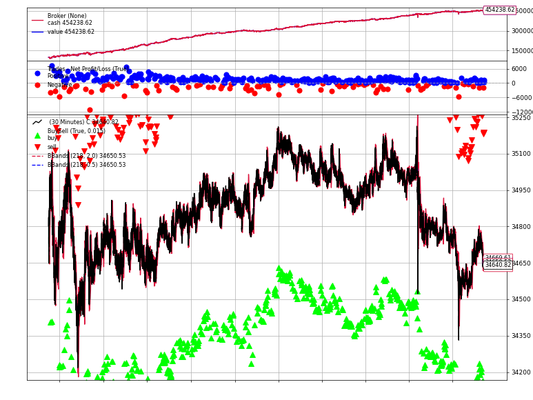

```
[[<Figure size 864x648 with 3 Axes>]]
```

```python
plt.ioff()
plt.rcParams['figure.figsize'] = [12, 9]
cerebro.plot(tight=False, volume=False)
```

```python
# Sharpe ratio
res[0].analyzers.sharperatio.get_analysis()
```

```
OrderedDict([('sharperatio', 1.3368989824418211)])
```

ANALYSIS

I am not going to include any post trade analysis, or optimisations. This is really the most important part. Judgements are required regarding entry / exit rules as well as several other factors. But it is worth the readers time to investigate further. GL.